# Part II - Flight Delays and What Causes Them

## by (Mackenzie Shonayi)

## Investigation Overview

> In this investigation my main focus is on delay distributions, relationship between delays and cancellation distribution.

## Dataset Overview

> The dataset im working with contains 27000 records of flights, from 1987 until 2020. My main focus in in delays columns because most of them contained nulls and they were not useful for my investigation

## Correlation between Arrival Delay vs Departure Delay

> There is a strong relationship between Arrival Delay and Departure Delay

```
Text(0,0.5,'Depature Delay (min)')
```

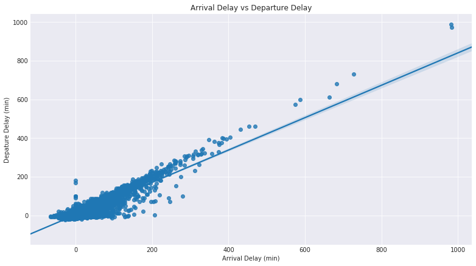

## Relationship between Carrier Delay and Departure Delay

> There is fair relationship between Carrier Delay and Depature Delay. This relationship is not very strong.

```
Text(0,0.5,'Depature Delay (min)')
```

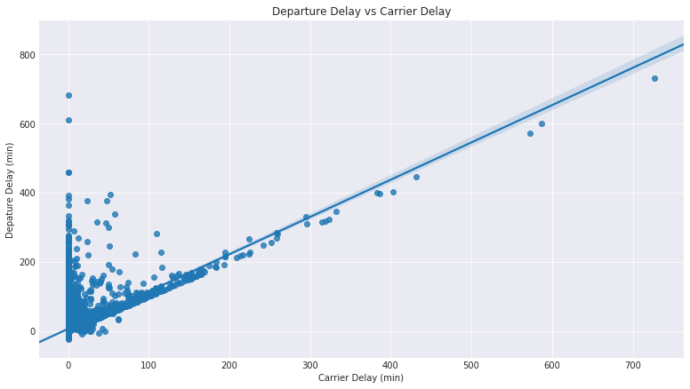

## Monthly distribution of Arrival Delay and Departure Delay

> Both Arrival and Departure delays have a very high value in the month of August and a very low value in the month of February. Which makes February the best month for travel.

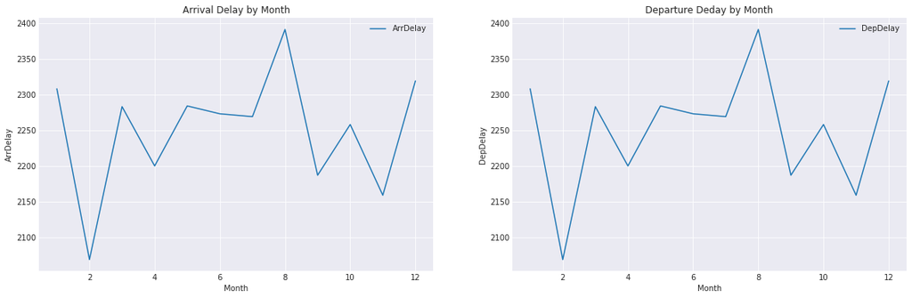

## City vs Depature Delay

> Atlanta (ATL) City has the highest number of Deputure Delays

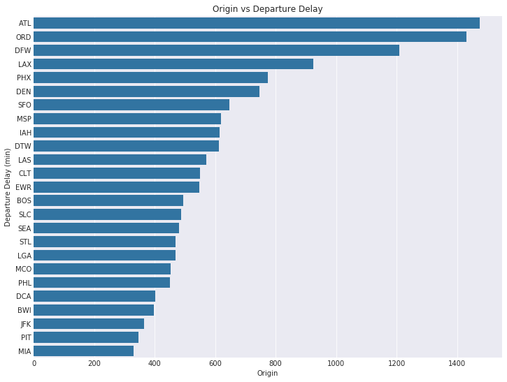

## Reasons for Monthly Flight Cancellations

> Weather(B) is the main reason for flight cancellations. With highest number of cancellations recorded in months of January, February and December

```
Text(0,0.5,'Flights')
```

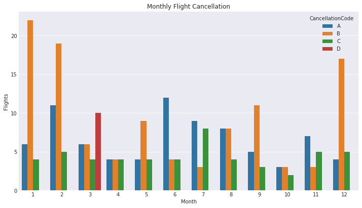

## Distribution of Delays Causes over the Years

```
Text(0.5,0,'Years')
```

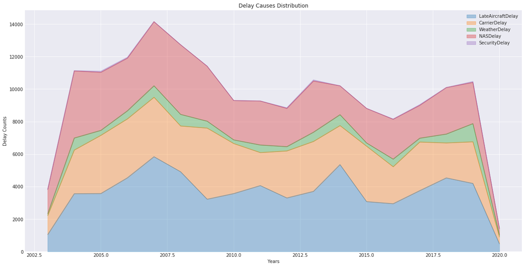